# Part I - (Prosper loans dataset presentation)

## Introduction

> This data set contains 113,937 loans with 81 variables on each loan, including loan amount, borrower rate (or interest rate), current loan status, borrower income, and many others

## Preliminary Wrangling

```python
# import all packages and set plots to be embedded inline
import numpy as np
import pandas as pd
import matplotlib.pyplot as plt
import seaborn as sns

%matplotlib inline
```

> Load in your dataset and describe its properties through the questions below. Try and motivate your exploration goals through this section.

```python
df = pd.read_csv('prosperLoanData.csv')
```

```python
df.head()
```

|  | ListingKey | ListingNumber | ListingCreationDate | CreditGrade | Term | LoanStatus | ClosedDate | BorrowerAPR | BorrowerRate | LenderYield | ... | LP_ServiceFees | LP_CollectionFees | LP_GrossPrincipalLoss | LP_NetPrincipalLoss | LP_NonPrincipalRecoverypayments | PercentFunded | Recommendations | InvestmentFromFriendsCount | InvestmentFromFriendsAmount | Investors |
| --- | --- | --- | --- | --- | --- | --- | --- | --- | --- | --- | --- | --- | --- | --- | --- | --- | --- | --- | --- | --- | --- |
| 0 | 1021339766868145413AB3B | 193129 | 2007-08-26 19:09:29.263000000 | C | 36 | Completed | 2009-08-14 00:00:00 | 0.16516 | 0.1580 | 0.1380 | ... | -133.18 | 0.0 | 0.0 | 0.0 | 0.0 | 1.0 | 0 | 0 | 0.0 | 258 |
| 1 | 10273602499503308B223C1 | 1209647 | 2014-02-27 08:28:07.900000000 | NaN | 36 | Current | NaN | 0.12016 | 0.0920 | 0.0820 | ... | 0.00 | 0.0 | 0.0 | 0.0 | 0.0 | 1.0 | 0 | 0 | 0.0 | 1 |
| 2 | 0EE9337825851032864889A | 81716 | 2007-01-05 15:00:47.090000000 | HR | 36 | Completed | 2009-12-17 00:00:00 | 0.28269 | 0.2750 | 0.2400 | ... | -24.20 | 0.0 | 0.0 | 0.0 | 0.0 | 1.0 | 0 | 0 | 0.0 | 41 |
| 3 | 0EF5356002482715299901A | 658116 | 2012-10-22 11:02:35.010000000 | NaN | 36 | Current | NaN | 0.12528 | 0.0974 | 0.0874 | ... | -108.01 | 0.0 | 0.0 | 0.0 | 0.0 | 1.0 | 0 | 0 | 0.0 | 158 |
| 4 | 0F023589499656230C5E3E2 | 909464 | 2013-09-14 18:38:39.097000000 | NaN | 36 | Current | NaN | 0.24614 | 0.2085 | 0.1985 | ... | -60.27 | 0.0 | 0.0 | 0.0 | 0.0 | 1.0 | 0 | 0 | 0.0 | 20 |

5 rows × 81 columns

```python
print(df.shape)
print("   ")
df.info()
```

```
(113937, 81)

<class 'pandas.core.frame.DataFrame'>
RangeIndex: 113937 entries, 0 to 113936
Data columns (total 81 columns):
 #   Column                               Non-Null Count   Dtype
---  ------                               --------------   -----
 0   ListingKey                           113937 non-null  object
 1   ListingNumber                        113937 non-null  int64
 2   ListingCreationDate                  113937 non-null  object
 3   CreditGrade                          28953 non-null   object
 4   Term                                 113937 non-null  int64
 5   LoanStatus                           113937 non-null  object
 6   ClosedDate                           55089 non-null   object
 7   BorrowerAPR                          113912 non-null  float64
```

[output cut: 75 more lines]

```python
# summary statistics of the variables
df.describe()
```

|  | ListingNumber | Term | BorrowerAPR | BorrowerRate | LenderYield | EstimatedEffectiveYield | EstimatedLoss | EstimatedReturn | ProsperRating (numeric) | ProsperScore | ... | LP_ServiceFees | LP_CollectionFees | LP_GrossPrincipalLoss | LP_NetPrincipalLoss | LP_NonPrincipalRecoverypayments | PercentFunded | Recommendations | InvestmentFromFriendsCount | InvestmentFromFriendsAmount | Investors |
| --- | --- | --- | --- | --- | --- | --- | --- | --- | --- | --- | --- | --- | --- | --- | --- | --- | --- | --- | --- | --- | --- |
| count | 1.139370e+05 | 113937.000000 | 113912.000000 | 113937.000000 | 113937.000000 | 84853.000000 | 84853.000000 | 84853.000000 | 84853.000000 | 84853.000000 | ... | 113937.000000 | 113937.000000 | 113937.000000 | 113937.000000 | 113937.000000 | 113937.000000 | 113937.000000 | 113937.000000 | 113937.000000 | 113937.000000 |
| mean | 6.278857e+05 | 40.830248 | 0.218828 | 0.192764 | 0.182701 | 0.168661 | 0.080306 | 0.096068 | 4.072243 | 5.950067 | ... | -54.725641 | -14.242698 | 700.446342 | 681.420499 | 25.142686 | 0.998584 | 0.048027 | 0.023460 | 16.550751 | 80.475228 |
| std | 3.280762e+05 | 10.436212 | 0.080364 | 0.074818 | 0.074516 | 0.068467 | 0.046764 | 0.030403 | 1.673227 | 2.376501 | ... | 60.675425 | 109.232758 | 2388.513831 | 2357.167068 | 275.657937 | 0.017919 | 0.332353 | 0.232412 | 294.545422 | 103.239020 |
| min | 4.000000e+00 | 12.000000 | 0.006530 | 0.000000 | -0.010000 | -0.182700 | 0.004900 | -0.182700 | 1.000000 | 1.000000 | ... | -664.870000 | -9274.750000 | -94.200000 | -954.550000 | 0.000000 | 0.700000 | 0.000000 | 0.000000 | 0.000000 | 1.000000 |
| 25% | 4.009190e+05 | 36.000000 | 0.156290 | 0.134000 | 0.124200 | 0.115670 | 0.042400 | 0.074080 | 3.000000 | 4.000000 | ... | -73.180000 | 0.000000 | 0.000000 | 0.000000 | 0.000000 | 1.000000 | 0.000000 | 0.000000 | 0.000000 | 2.000000 |
| 50% | 6.005540e+05 | 36.000000 | 0.209760 | 0.184000 | 0.173000 | 0.161500 | 0.072400 | 0.091700 | 4.000000 | 6.000000 | ... | -34.440000 | 0.000000 | 0.000000 | 0.000000 | 0.000000 | 1.000000 | 0.000000 | 0.000000 | 0.000000 | 44.000000 |
| 75% | 8.926340e+05 | 36.000000 | 0.283810 | 0.250000 | 0.240000 | 0.224300 | 0.112000 | 0.116600 | 5.000000 | 8.000000 | ... | -13.920000 | 0.000000 | 0.000000 | 0.000000 | 0.000000 | 1.000000 | 0.000000 | 0.000000 | 0.000000 | 115.000000 |
| max | 1.255725e+06 | 60.000000 | 0.512290 | 0.497500 | 0.492500 | 0.319900 | 0.366000 | 0.283700 | 7.000000 | 11.000000 | ... | 32.060000 | 0.000000 | 25000.000000 | 25000.000000 | 21117.900000 | 1.012500 | 39.000000 | 33.000000 | 25000.000000 | 1189.000000 |

8 rows × 61 columns

```python
df.dtypes
```

```
ListingKey                      object
ListingNumber                    int64
ListingCreationDate             object
CreditGrade                     object
Term                             int64
                                ...
PercentFunded                  float64
Recommendations                  int64
InvestmentFromFriendsCount       int64
InvestmentFromFriendsAmount    float64
Investors                        int64
Length: 81, dtype: object
```

### What is the structure of your dataset?

> The dataset has 113,937 records, and 81 columns\variables

### What is/are the main feature(s) of interest in your dataset?

> There are many featuers like ProsperRating,BorrowerRate,Investors. But I want to know the average income and why they take loans

### What features in the dataset do you think will help support your investigation into your feature(s) of interest?

> ListingNumber ,Occupation ,LoanStatus ,ListingCategory ,ProsperRating(Alpha) ,EmploymentStatus ,EmploymentStatusDuration ,IncomeRange ,StatedMonthlyIncome ,MonthlyLoanPayment ,BorrowerAPR ,LoanOriginalAmount

```python
#making new dataframe of colomns i selected
df2 = df[['ListingNumber','Occupation', 'LoanStatus', 'ListingCategory (numeric)' , 'ProsperRating (Alpha)','Investors','EmploymentStatus','EmploymentStatusDuration','IncomeRange','StatedMonthlyIncome','MonthlyLoanPayment','BorrowerAPR','LoanOriginalAmount']]
```

```python
df2.head()
```

|  | ListingNumber | Occupation | LoanStatus | ListingCategory (numeric) | ProsperRating (Alpha) | Investors | EmploymentStatus | EmploymentStatusDuration | IncomeRange | StatedMonthlyIncome | MonthlyLoanPayment | BorrowerAPR | LoanOriginalAmount |
| --- | --- | --- | --- | --- | --- | --- | --- | --- | --- | --- | --- | --- | --- |
| 0 | 193129 | Other | Completed | 0 | NaN | 258 | Self-employed | 2.0 | $25,000-49,999 | 3083.333333 | 330.43 | 0.16516 | 9425 |
| 1 | 1209647 | Professional | Current | 2 | A | 1 | Employed | 44.0 | $50,000-74,999 | 6125.000000 | 318.93 | 0.12016 | 10000 |
| 2 | 81716 | Other | Completed | 0 | NaN | 41 | Not available | NaN | Not displayed | 2083.333333 | 123.32 | 0.28269 | 3001 |
| 3 | 658116 | Skilled Labor | Current | 16 | A | 158 | Employed | 113.0 | $25,000-49,999 | 2875.000000 | 321.45 | 0.12528 | 10000 |
| 4 | 909464 | Executive | Current | 2 | D | 20 | Employed | 44.0 | $100,000+ | 9583.333333 | 563.97 | 0.24614 | 15000 |

```python
print(df2.shape)
print(df2.dtypes)
```

```
(113937, 13)
ListingNumber                  int64
Occupation                    object
LoanStatus                    object
ListingCategory (numeric)      int64
ProsperRating (Alpha)         object
Investors                      int64
EmploymentStatus              object
EmploymentStatusDuration     float64
IncomeRange                   object
StatedMonthlyIncome          float64
MonthlyLoanPayment           float64
BorrowerAPR                  float64
LoanOriginalAmount             int64
dtype: object
```

```python
df2.describe()
```

|  | ListingNumber | ListingCategory (numeric) | Investors | EmploymentStatusDuration | StatedMonthlyIncome | MonthlyLoanPayment | BorrowerAPR | LoanOriginalAmount |
| --- | --- | --- | --- | --- | --- | --- | --- | --- |
| count | 1.139370e+05 | 113937.000000 | 113937.000000 | 106312.000000 | 1.139370e+05 | 113937.000000 | 113912.000000 | 113937.00000 |
| mean | 6.278857e+05 | 2.774209 | 80.475228 | 96.071582 | 5.608026e+03 | 272.475783 | 0.218828 | 8337.01385 |
| std | 3.280762e+05 | 3.996797 | 103.239020 | 94.480605 | 7.478497e+03 | 192.697812 | 0.080364 | 6245.80058 |
| min | 4.000000e+00 | 0.000000 | 1.000000 | 0.000000 | 0.000000e+00 | 0.000000 | 0.006530 | 1000.00000 |
| 25% | 4.009190e+05 | 1.000000 | 2.000000 | 26.000000 | 3.200333e+03 | 131.620000 | 0.156290 | 4000.00000 |
| 50% | 6.005540e+05 | 1.000000 | 44.000000 | 67.000000 | 4.666667e+03 | 217.740000 | 0.209760 | 6500.00000 |
| 75% | 8.926340e+05 | 3.000000 | 115.000000 | 137.000000 | 6.825000e+03 | 371.580000 | 0.283810 | 12000.00000 |
| max | 1.255725e+06 | 20.000000 | 1189.000000 | 755.000000 | 1.750003e+06 | 2251.510000 | 0.512290 | 35000.00000 |

```python
# percentage number of missing values per column
df2.isna().sum()/len(df2)
```

```
ListingNumber                0.000000
Occupation                   0.031491
LoanStatus                   0.000000
ListingCategory (numeric)    0.000000
ProsperRating (Alpha)        0.255264
Investors                    0.000000
EmploymentStatus             0.019792
EmploymentStatusDuration     0.066923
IncomeRange                  0.000000
StatedMonthlyIncome          0.000000
MonthlyLoanPayment           0.000000
BorrowerAPR                  0.000219
LoanOriginalAmount           0.000000
dtype: float64
```

```python
# As ProsperRating (Alpha) nearly 25% of it missing so we better not deal with it
df2.drop(columns='ProsperRating (Alpha)',inplace=True)
```

```python
#Renaming columns to ease exploring
df2 = df2.rename(columns = {'ListingCategory (numeric)': 'ListingCategory'})
```

```python
# #Renaming columns to ease exploring
# df2 = df2.rename(columns = {'ProsperRating (Alpha)': 'ProsperRating'})
```

```python
#eliminating missing values
df2.dropna(how='any', inplace=True)
```

```python
df2.shape
```

```
(104985, 12)
```

```python
# Checking duplicated rows
df2.duplicated().sum()
```

```
812
```

```python
#drop Duplicates
df2.drop_duplicates(keep='first',inplace=True)
```

## Univariate Exploration

```python
def count_plot(df,y_col,ord_cat,title_plt):
    sns.countplot(data=df, y= y_col,order = ord_cat);
    plt.title(title_plt);
```

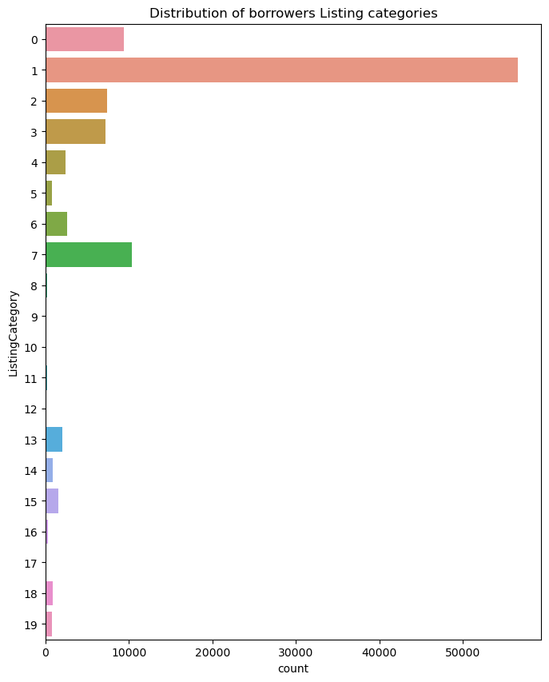

```python
plt.figure(figsize=[8, 10]);
count_plot(df2,'ListingCategory',[i for i in range(20)],"Distribution of borrowers Listing categories");
```

The top 5 reasons borrowers request a loan and a listed for are:

1. **Debt consolidation** ( 1 )
2. **Other** ( 7 )
3. **Not Available** ( 0 )
4. **Home improvement** ( 2 )
5. **Business** ( 3 )